# Data Visualization With Stata

Andy Grogan-Kaylor

22 Feb 2022 18:13:56

# Introduction

- Stata is a powerful and intuitive data analysis program.
- Learning how to graph in Stata is an important part of learning how to use Stata. Yet, the default graphs in Stata can sometimes be less than optimal.
- This document is an introduction to (a) basic graphing ideas in Stata; and (b) some simple ways to make your Stata graphs look more professional.
- If this document is presented as slides, navigation links are in the corner of this slide deck.
- If this document is presented as slides, you can generate a printable version of these slides, by clicking on the “Ø”.

# What are Variables?

- By variables, I simply mean the columns of data that you have.
- For our purposes, you may think of variables as synonymous with questionnaire items, or columns of data.

# Variable Types

- *categorical variables* represent unordered categories like *neighborhood*, or *religious affiliation*, or *place of residence*.
- *continuous variables* represent a continuous scale like a *mental health scale*, or a *measure of life expectancy*.

# A Data Visualization Strategy

Once we have discerned the type of variable that have, there are two followup questions we may ask before deciding upon a chart strategy:

- Is our graph about **one thing at a time**?
  - How much of *x* is there?
  - What is the distribution of *x*?
- Is our graph about **two things at a time**?
  - What is the relationship of *x* and *y*?
  - How are *x* and *y* associated?

# Data

We are going to use the famous “iris” data collected by Edgar Anderson in the early 20th Century.

```stata
. use "iris.dta", clear

.
. summarize

    Variable │        Obs        Mean    Std. dev.       Min        Max
─────────────┼─────────────────────────────────────────────────────────
Sepal_Length │        150    5.843333    .8280661        4.3        7.9
 Sepal_Width │        150    3.057333    .4358663          2        4.4
Petal_Length │        150       3.758    1.765298          1        6.9
 Petal_Width │        150    1.199333    .7622377         .1        2.5
     Species │        150           2    .8192319          1          3
```

> The `iris` data set has 5 variables.

# Species of Iris

> Iris species images courtesy [Wikipedia](https://www.wikipedia.org/).

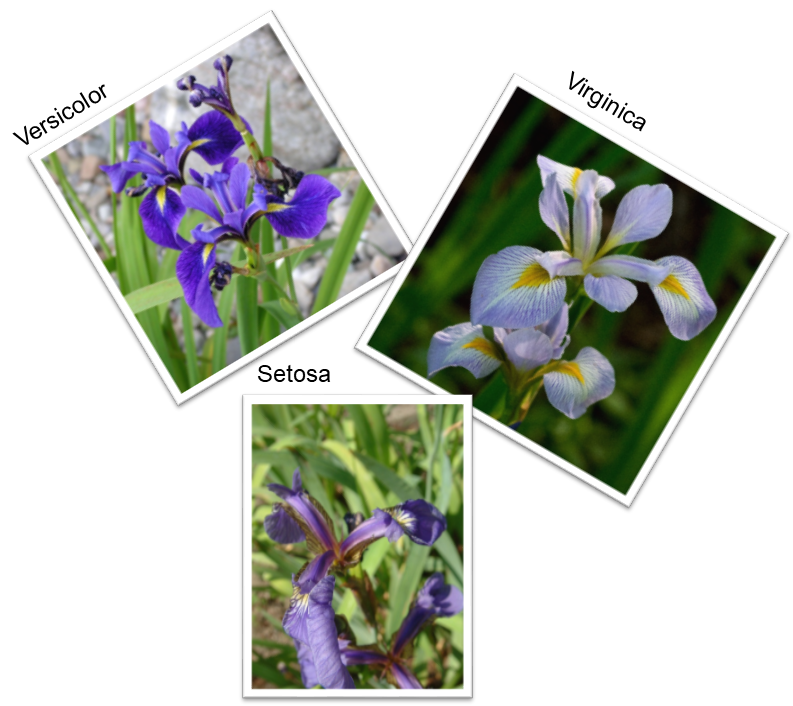

Iris Species

# Petals and Sepals

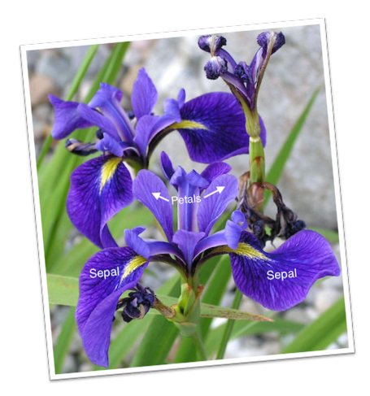

Petals and Sepals

# Continuous Variable `histogram`

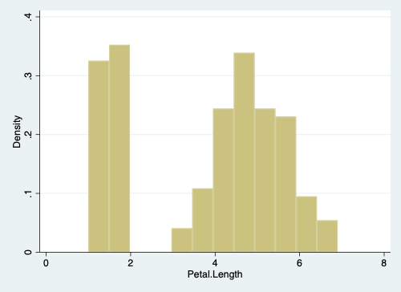

```stata
. histogram Petal_Length
(bin=12, start=1, width=.49166667)
```

# Categorical Variable `graph bar`

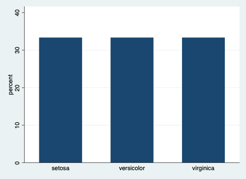

Bar Graph of Species

```stata
. graph bar, over(Species)
```

# Continuous by Continuous `twoway`

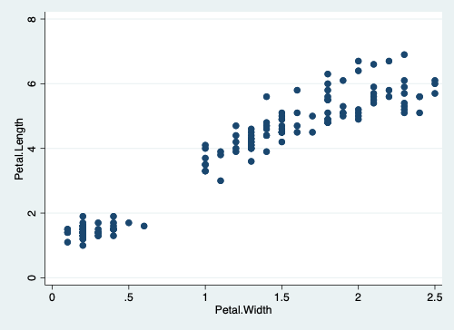

Scatterplot

```stata
. twoway scatter Petal_Length Petal_Width
```

# Categorical by Categorical `graph bar`

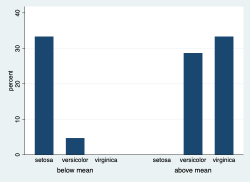

Bar Graph of Species by Category of Petal Length

```stata
. recode Petal_Length ///
> (min/3.758 = 0 "below mean") ///
> (3.758/max = 1 "above mean"), ///
> generate(Petal_Group) // dichotomize Petal_Length
(150 differences between Petal_Length and Petal_Group)

.
. graph bar, over(Species) over(Petal_Group)
```

# Continuous by Categorical `graph bar`

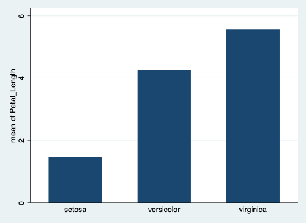

Bar Graph of Petal Length by Species

```stata
. graph bar Petal_Length, over(Species)
```

# Titles and Labels `, title(...) xtitle(...) ytitle(...)`

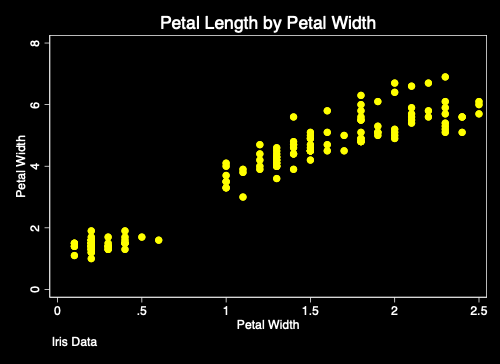

Graph With Titles and Labels

```stata
. twoway scatter Petal_Length Petal_Width, scheme(s1rcolor) ///
> title("Petal Length by Petal Width") ///
> xtitle("Petal Width") ytitle("Petal Width") ///
> caption("Iris Data")
```

# Better Graphing With Schemes `,scheme(...)`

The easiest method to make better Stata graphs is through the use of predefined Stata graphing schemes.

# Pre-Defined Schemes

Some schemes, e.g. `economist`, `sj`, `s1color`, and `s1rcolor` are pre-installed with Stata.

# Economist Scheme

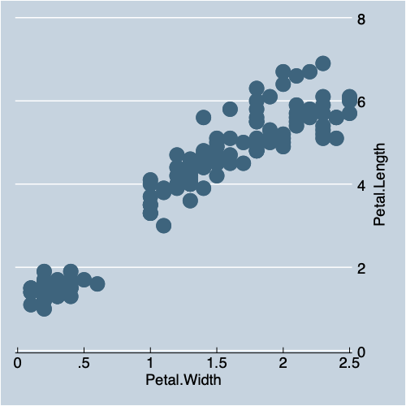

Scatterplot with Economist Scheme

```stata
. twoway scatter Petal_Length Petal_Width, scheme(economist)
```

# *Stata Journal* Scheme

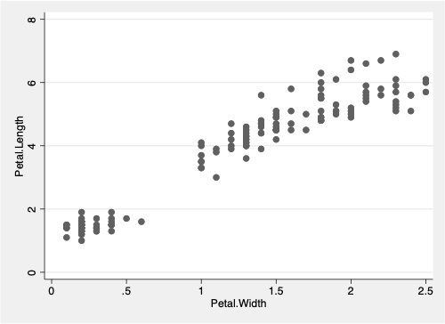

Scatterplot with *Stata Journal* Scheme

```stata
. twoway scatter Petal_Length Petal_Width, scheme(sj)
```

# `s1color` Scheme

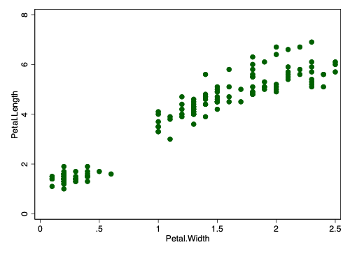

Scatterplot with `s1color` Scheme

```stata
. twoway scatter Petal_Length Petal_Width, scheme(s1color)
```

# `s1rcolor` Scheme

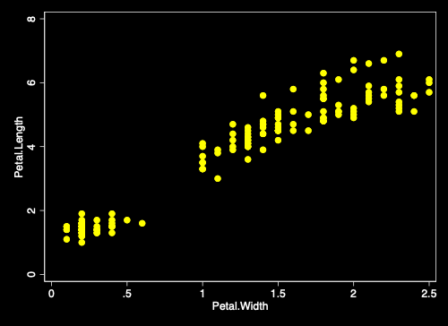

Scatterplot with `s1rcolor` Scheme

```stata
. twoway scatter Petal_Length Petal_Width, scheme(s1rcolor)
```

# User Written Schemes

Two of the best user written schemes are `plottig` and `lean2`.

Use the `findit` command e.g. `findit lean2` to find these schemes.

# `lean2` Scheme

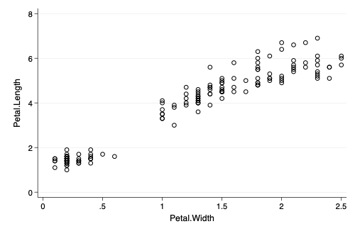

Scatterplot with `lean2` Scheme

```stata
. twoway scatter Petal_Length Petal_Width, scheme(lean2)
```

# Michigan graph scheme

I have written a `michigan` graph scheme described [here](https://agrogan1.github.io/Stata/).

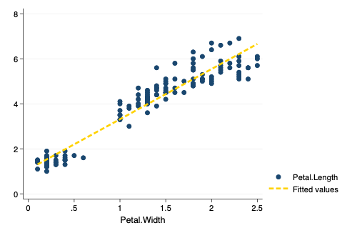

Scatterplot with `michigan` Scheme

```stata
. twoway (scatter Petal_Length Petal_Width) ///
> (lfit Petal_Length Petal_Width), scheme(michigan)
```

# Schemes as a Base for Further Tweaking

Schemes can be used as a base that can then be further modified.

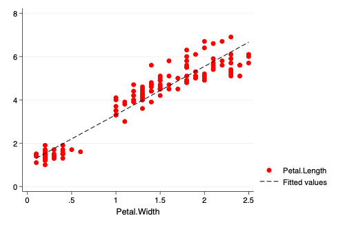

Modified Scatterplot with `lean2` Scheme as a Base

```stata
. twoway (scatter Petal_Length Petal_Width, msymbol(0) mcolor(red)) ///
> (lfit Petal_Length Petal_Width), ///
> scheme(lean2)
(note:  named style 0 not found in class symbol, default attributes used)
```

# Even More Tweaks

Based upon an example at https://blog.stata.com/2018/10/02/scheming-your-way-to-your-favorite-graph-style/

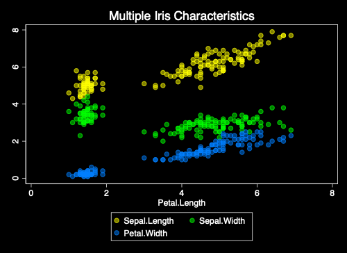

Modified Scatterplot with `s1rcolor` Scheme as a Base

```stata
. twoway scatter Sepal_Length Sepal_Width Petal_Width Petal_Length, ///
> color(%50 %50 %50) /// transparency
> title("Multiple Iris Characteristics") /// title
> scheme(s1rcolor) // scheme
```

# More Information

See also [Two Page Stata](https://agrogan1.github.io/Stata/two-page-stata/TwoPageStata.pdf)

Created by agrogan@umich.edu